# Comparison of machine learning-based models for early diagnosis and prediction of lung cancer

BMIN503/EPID600 Final Project

Author

Yue Cao

## 2 Introduction

Lung cancer is one of the leading causes of cancer-related deaths globally and is often diagnosed at an advanced stage, limiting treatment options and reducing survival rates. Early detection plays a crucial role in improving patient outcomes, but current diagnostic practices primarily rely on subjective assessments and are prone to inefficiencies. The aim of this project is to develop a machine learning-based predictive model for lung cancer diagnosis, using patient data to identify key risk factors and improve diagnostic accuracy. This data-driven approach focuses on reducing false positives and enhancing clinical decision-making efficiency, ultimately supporting clinicians in early detection efforts.

Collaborations with Dr. Mowery and Dr. Fan were instrumental in shaping this project. Dr. Fan provided critical insights into the clinical presentation, risk factors, and diagnostic challenges associated with lung cancer, while Dr. Mowery highlighted the importance of minimizing false-positive rates to ensure actionable results. This project leverages advanced machine learning techniques, informed by their guidance, to analyze structured data and evaluate predictive performance. By focusing solely on patient data, the study demonstrates the potential of machine learning in streamlining lung cancer diagnosis and supporting evidence-based clinical practices.

## 3 Methods

The analysis focuses on a dataset (survey lung cancer.csv) with information about individuals, including factors potentially influencing lung cancer incidence. Each row represents a respondent, and columns capture variables like smoking habits, gender, symptoms, and diagnoses.

The primary objective is to predict the presence of lung cancer (LUNG_CANCER), a binary outcome. A robust methodological approach ensures the dataset is cleaned, analyzed, and modeled effectively. The steps include:

```r
library(dplyr)
library(ggplot2)
library(readr)

options(warn = -1)

df <- read_csv('survey lung cancer.csv')
print(df)
```

```
# A tibble: 309 × 16
   GENDER   AGE SMOKING YELLOW_FINGERS ANXIETY PEER_PRESSURE `CHRONIC DISEASE`
   <chr>  <dbl>   <dbl>          <dbl>   <dbl>         <dbl>             <dbl>
 1 M         69       1              2       2             1                 1
 2 M         74       2              1       1             1                 2
 3 F         59       1              1       1             2                 1
 4 M         63       2              2       2             1                 1
 5 F         63       1              2       1             1                 1
 6 F         75       1              2       1             1                 2
 7 M         52       2              1       1             1                 1
 8 F         51       2              2       2             2                 1
 9 F         68       2              1       2             1                 1
10 M         53       2              2       2             2                 2
# ℹ 299 more rows
# ℹ 9 more variables: FATIGUE <dbl>, ALLERGY <dbl>, WHEEZING <dbl>,
#   `ALCOHOL CONSUMING` <dbl>, COUGHING <dbl>, `SHORTNESS OF BREATH` <dbl>,
#   `SWALLOWING DIFFICULTY` <dbl>, `CHEST PAIN` <dbl>, LUNG_CANCER <chr>
```

Note: In this dataset, YES=2 & NO=1

```r
dim(df)
```

```
[1] 309  16
```

```r
sum(duplicated(df))
```

```
[1] 33
```

```r
df <- df[!duplicated(df), ]
colSums(is.na(df))
```

```
               GENDER                   AGE               SMOKING
                    0                     0                     0
       YELLOW_FINGERS               ANXIETY         PEER_PRESSURE
                    0                     0                     0
      CHRONIC DISEASE               FATIGUE               ALLERGY
                    0                     0                     0
             WHEEZING     ALCOHOL CONSUMING              COUGHING
                    0                     0                     0
  SHORTNESS OF BREATH SWALLOWING DIFFICULTY            CHEST PAIN
                    0                     0                     0
          LUNG_CANCER
                    0
```

```r
names(df) <- trimws(names(df))
names(df)
```

```
 [1] "GENDER"                "AGE"                   "SMOKING"
 [4] "YELLOW_FINGERS"        "ANXIETY"               "PEER_PRESSURE"
 [7] "CHRONIC DISEASE"       "FATIGUE"               "ALLERGY"
[10] "WHEEZING"              "ALCOHOL CONSUMING"     "COUGHING"
[13] "SHORTNESS OF BREATH"   "SWALLOWING DIFFICULTY" "CHEST PAIN"
[16] "LUNG_CANCER"
```

```r
df$GENDER <- as.numeric(factor(df$GENDER)) - 1
df$LUNG_CANCER <- as.numeric(factor(df$LUNG_CANCER)) - 1
df$SMOKING <- as.numeric(factor(df$SMOKING)) - 1
df$YELLOW_FINGERS <- as.numeric(factor(df$YELLOW_FINGERS)) - 1
df$ANXIETY <- as.numeric(factor(df$ANXIETY)) - 1
df$PEER_PRESSURE <- as.numeric(factor(df$PEER_PRESSURE)) - 1
df$`CHRONIC DISEASE` <- as.numeric(factor(df$`CHRONIC DISEASE`)) - 1
df$FATIGUE <- as.numeric(factor(df$FATIGUE)) - 1
df$ALLERGY <- as.numeric(factor(df$ALLERGY)) - 1
df$WHEEZING <- as.numeric(factor(df$WHEEZING)) - 1
df$`ALCOHOL CONSUMING` <- as.numeric(factor(df$`ALCOHOL CONSUMING`)) - 1
df$COUGHING <- as.numeric(factor(df$COUGHING)) - 1
df$`SHORTNESS OF BREATH` <- as.numeric(factor(df$`SHORTNESS OF BREATH`)) - 1
df$`SWALLOWING DIFFICULTY` <- as.numeric(factor(df$`SWALLOWING DIFFICULTY`)) - 1
df$`CHEST PAIN` <- as.numeric(factor(df$`CHEST PAIN`)) - 1

df
```

```
# A tibble: 276 × 16
   GENDER   AGE SMOKING YELLOW_FINGERS ANXIETY PEER_PRESSURE `CHRONIC DISEASE`
    <dbl> <dbl>   <dbl>          <dbl>   <dbl>         <dbl>             <dbl>
 1      1    69       0              1       1             0                 0
 2      1    74       1              0       0             0                 1
 3      0    59       0              0       0             1                 0
 4      1    63       1              1       1             0                 0
 5      0    63       0              1       0             0                 0
 6      0    75       0              1       0             0                 1
 7      1    52       1              0       0             0                 0
 8      0    51       1              1       1             1                 0
 9      0    68       1              0       1             0                 0
10      1    53       1              1       1             1                 1
# ℹ 266 more rows
# ℹ 9 more variables: FATIGUE <dbl>, ALLERGY <dbl>, WHEEZING <dbl>,
#   `ALCOHOL CONSUMING` <dbl>, COUGHING <dbl>, `SHORTNESS OF BREATH` <dbl>,
#   `SWALLOWING DIFFICULTY` <dbl>, `CHEST PAIN` <dbl>, LUNG_CANCER <dbl>
```

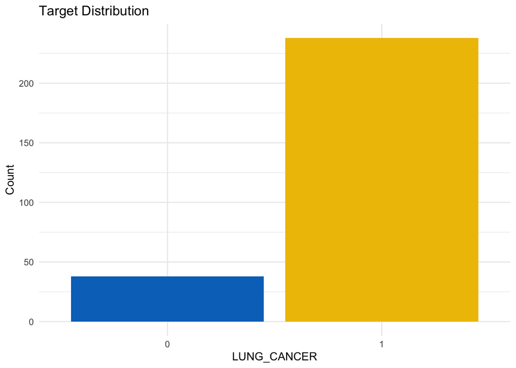

```r
ggplot(df, aes(x = as.factor(LUNG_CANCER), fill = as.factor(LUNG_CANCER))) +
  geom_bar() +
  scale_fill_manual(values = c("#0073C2FF", "#EFC000FF")) +
  labs(title = "Target Distribution", x = "LUNG_CANCER", y = "Count") +
  theme_minimal() +
  theme(legend.position = "none")
```

```r
table(df$LUNG_CANCER)
```

```
  0   1
 38 238
```

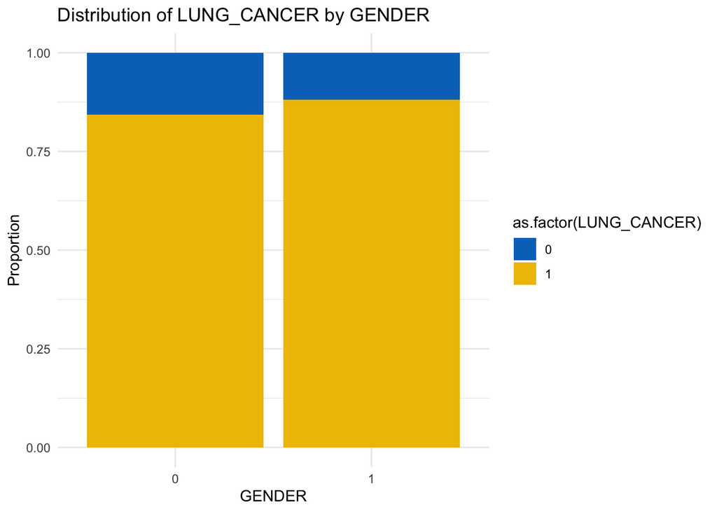

```r
plot_distribution <- function(col_name, df) {
  library(ggplot2)

  ggplot(df, aes(x = as.factor(get(col_name)), fill = as.factor(LUNG_CANCER))) +
    geom_bar(position = "fill", stat = "count") +
    scale_fill_manual(values = c("#0073C2FF", "#EFC000FF")) +
    labs(
      title = paste("Distribution of LUNG_CANCER by", col_name),
      x = col_name,
      y = "Proportion"
    ) +
    theme_minimal()
}

plot_distribution("GENDER", df)
```

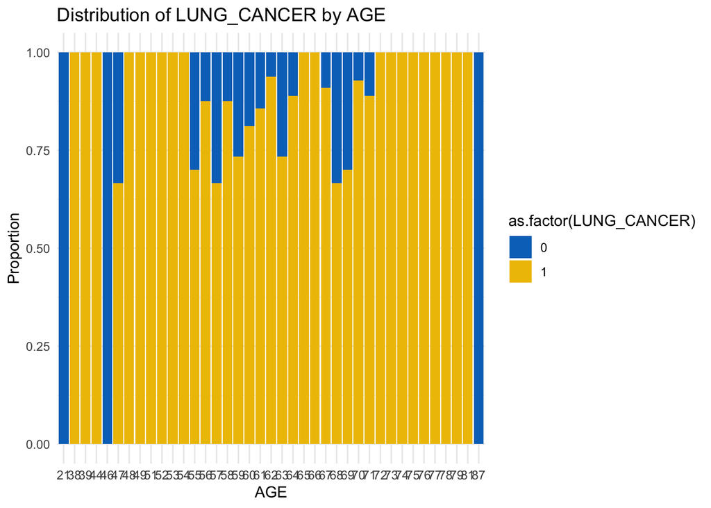

```r
plot_distribution("AGE", df)
```

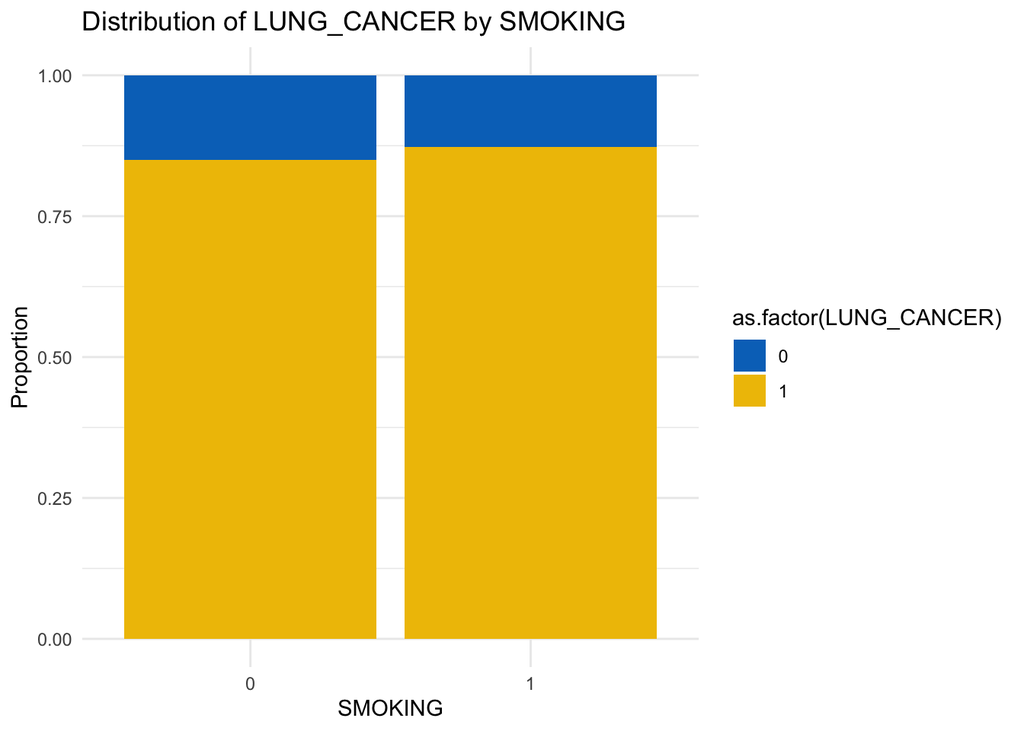

```r
plot_distribution("SMOKING", df)
```

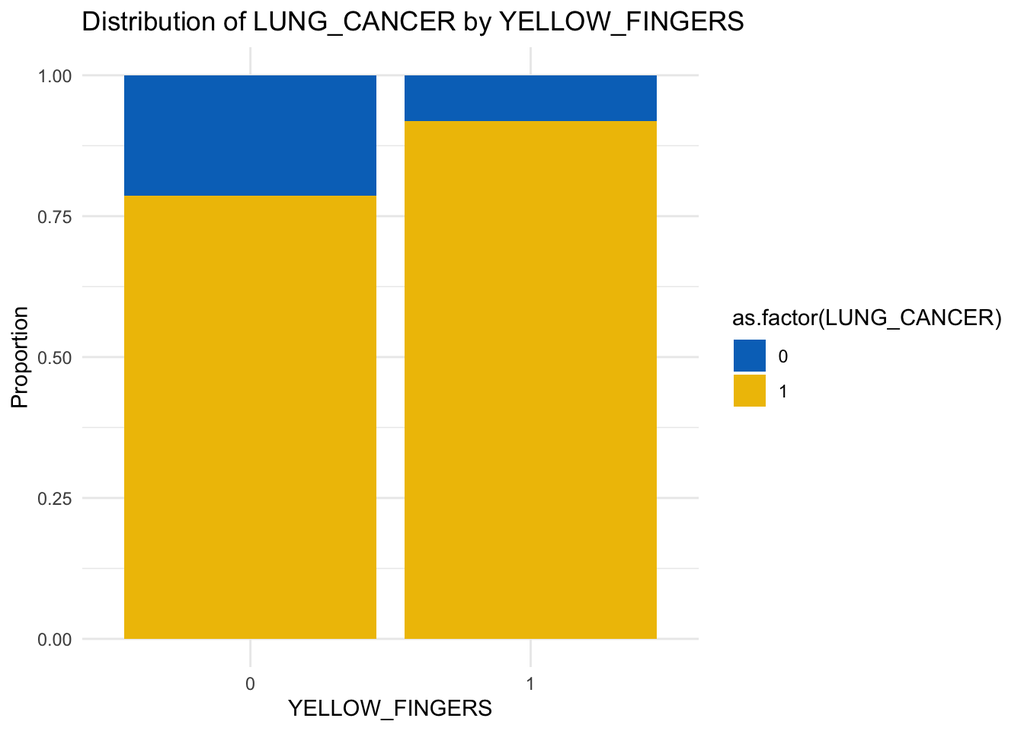

```r
plot_distribution("YELLOW_FINGERS", df)
```

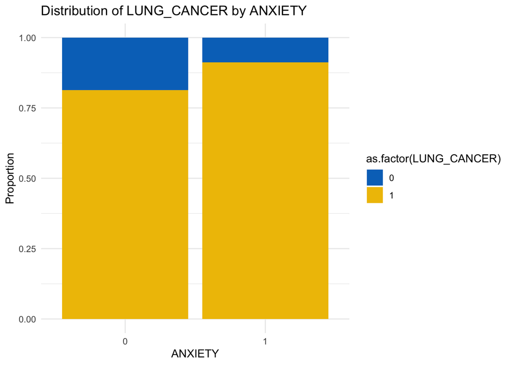

```r
plot_distribution("ANXIETY", df)
```

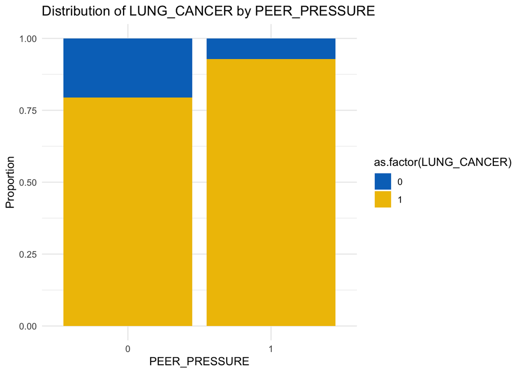

```r
plot_distribution("PEER_PRESSURE", df)
```

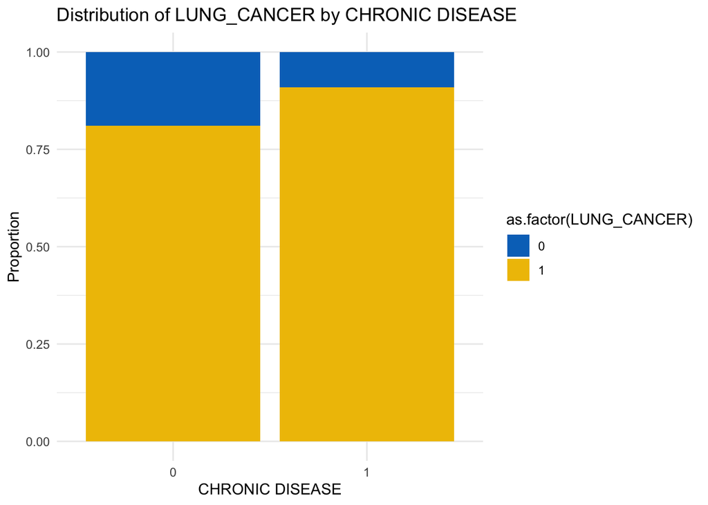

```r
plot_distribution("CHRONIC DISEASE", df)
```

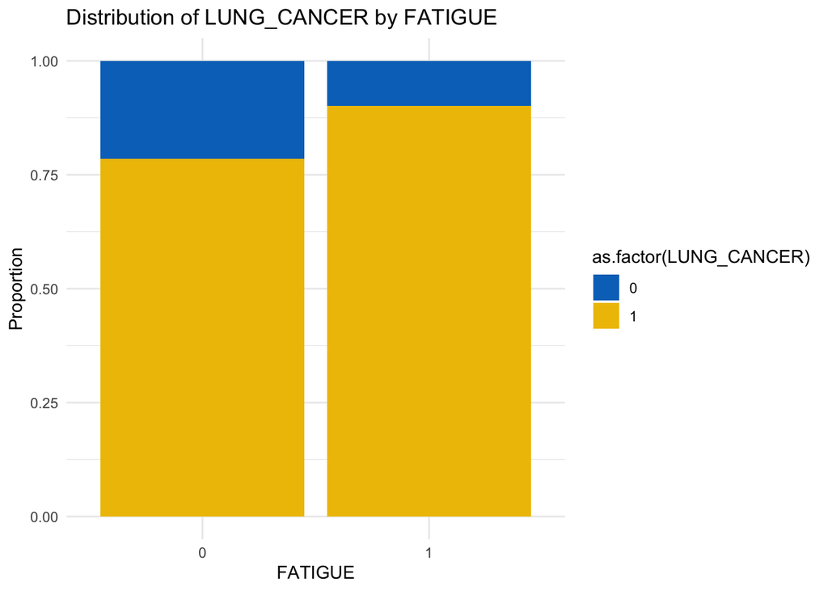

```r
plot_distribution("FATIGUE", df)
```

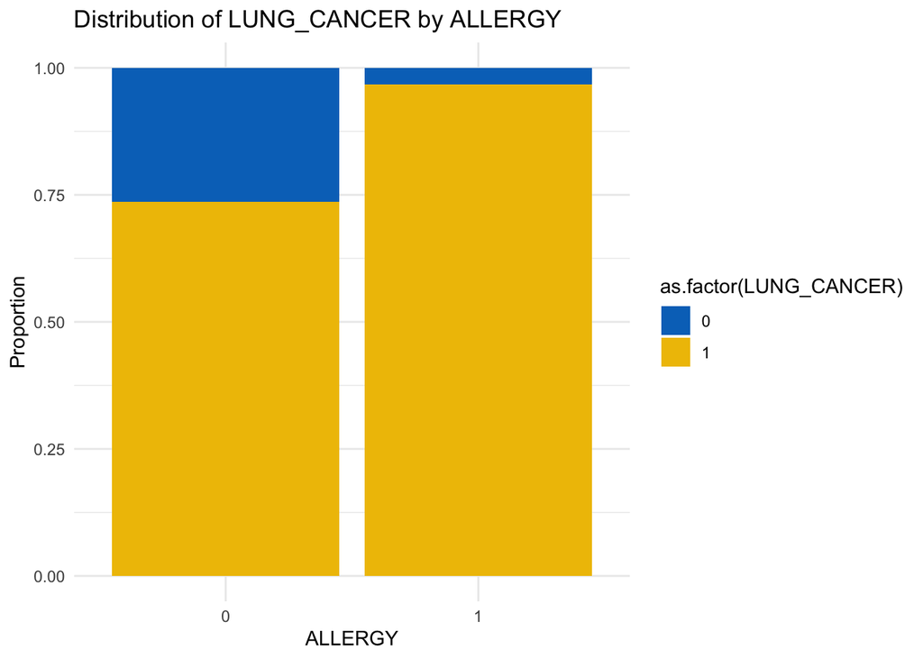

```r
plot_distribution("ALLERGY", df)
```

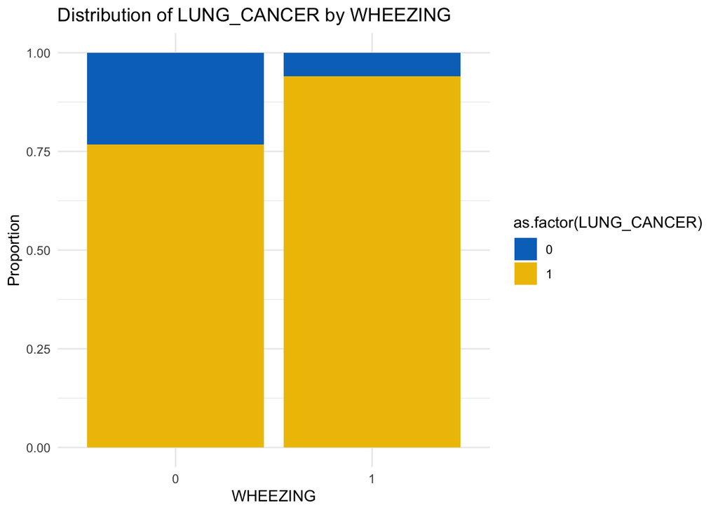

```r
plot_distribution("WHEEZING", df)
```

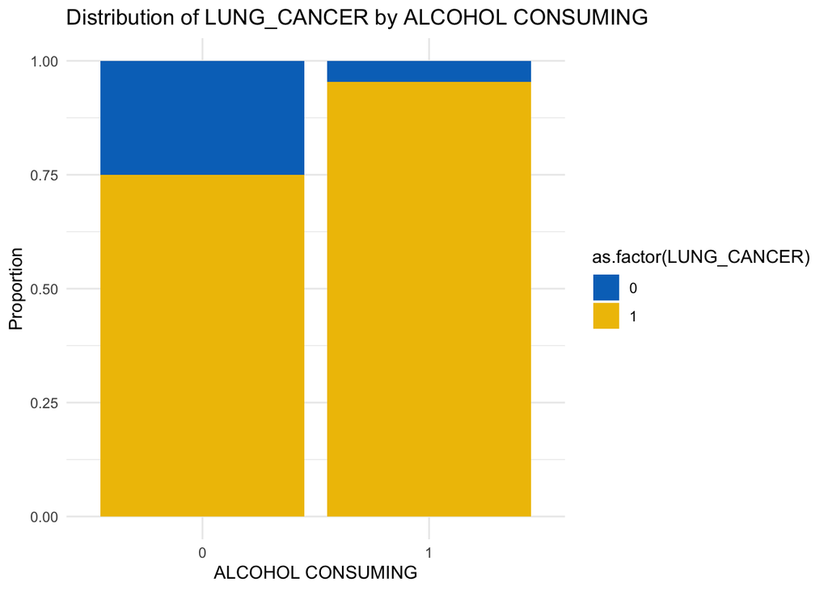

```r
plot_distribution("ALCOHOL CONSUMING", df)
```

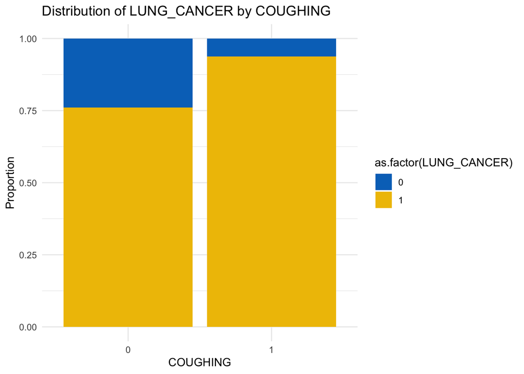

```r
plot_distribution("COUGHING", df)
```

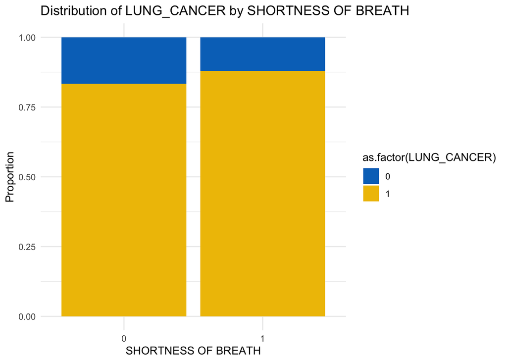

```r
plot_distribution("SHORTNESS OF BREATH", df)
```

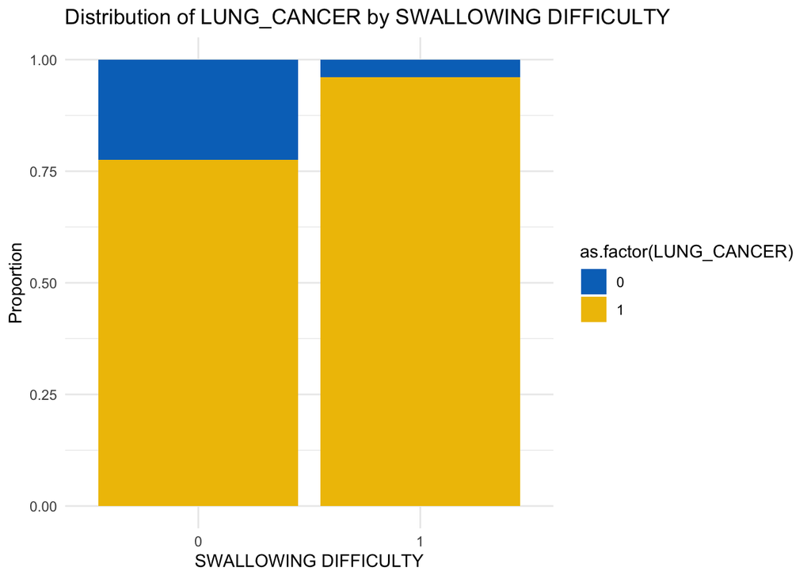

```r
plot_distribution("SWALLOWING DIFFICULTY", df)
```

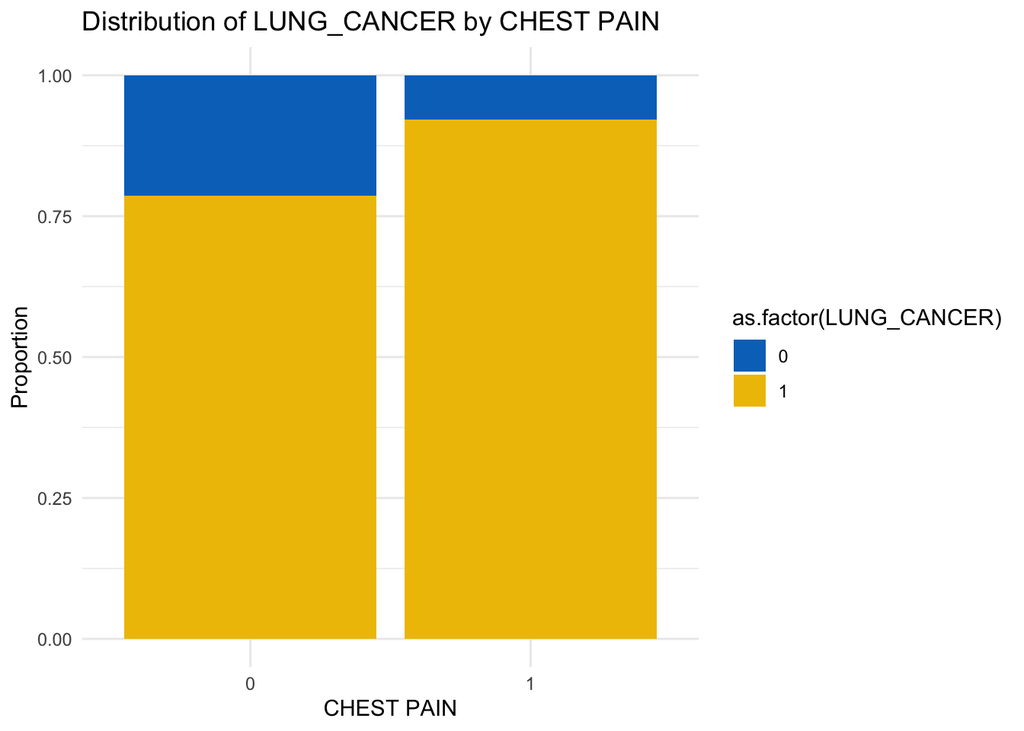

```r
plot_distribution("CHEST PAIN", df)
```

```r
# Based on the visualizations, it is evident that the features GENDER, AGE, SMOKING, and SHORTNESS OF BREATH show minimal correlation with LUNG CANCER in the dataset. Therefore, we can remove these features to streamline and refine the dataset.
```

```r
df_new <- df %>% select(-GENDER, -AGE, -SMOKING, -`SHORTNESS OF BREATH`)
names(df_new) <- gsub(" ", "_", names(df_new))

print(names(df_new))
```

```
 [1] "YELLOW_FINGERS"        "ANXIETY"               "PEER_PRESSURE"
 [4] "CHRONIC_DISEASE"       "FATIGUE"               "ALLERGY"
 [7] "WHEEZING"              "ALCOHOL_CONSUMING"     "COUGHING"
[10] "SWALLOWING_DIFFICULTY" "CHEST_PAIN"            "LUNG_CANCER"
```

```r
print(df_new)
```

```
# A tibble: 276 × 12
   YELLOW_FINGERS ANXIETY PEER_PRESSURE CHRONIC_DISEASE FATIGUE ALLERGY WHEEZING
            <dbl>   <dbl>         <dbl>           <dbl>   <dbl>   <dbl>    <dbl>
 1              1       1             0               0       1       0        1
 2              0       0             0               1       1       1        0
 3              0       0             1               0       1       0        1
 4              1       1             0               0       0       0        0
 5              1       0             0               0       0       0        1
 6              1       0             0               1       1       1        1
 7              0       0             0               0       1       0        1
 8              1       1             1               0       1       1        0
 9              0       1             0               0       1       0        0
10              1       1             1               1       0       1        0
# ℹ 266 more rows
# ℹ 5 more variables: ALCOHOL_CONSUMING <dbl>, COUGHING <dbl>,
#   SWALLOWING_DIFFICULTY <dbl>, CHEST_PAIN <dbl>, LUNG_CANCER <dbl>
```

```r
library(ggplot2)
library(reshape2)
library(corrplot)
df_numeric <- df_new[, sapply(df_new, is.numeric)]

cn <- cor(df_numeric, use = "complete.obs")

print(cn)
```

```
                      YELLOW_FINGERS     ANXIETY PEER_PRESSURE CHRONIC_DISEASE
YELLOW_FINGERS            1.00000000  0.55834447    0.31306735      0.01531556
ANXIETY                   0.55834447  1.00000000    0.21027755     -0.00693806
PEER_PRESSURE             0.31306735  0.21027755    1.00000000      0.04289320
CHRONIC_DISEASE           0.01531556 -0.00693806    0.04289320      1.00000000
FATIGUE                  -0.09964379 -0.18147401    0.09466057     -0.09941051
ALLERGY                  -0.14713019 -0.15945090   -0.06688709      0.13430909
WHEEZING                 -0.05875602 -0.17400878   -0.03776905     -0.04054614
ALCOHOL_CONSUMING        -0.27364341 -0.15222814   -0.13260305      0.01014379
COUGHING                  0.02080310 -0.21884298   -0.06822445     -0.16081334
SWALLOWING_DIFFICULTY     0.33334864  0.47882019    0.32776427      0.06826267
CHEST_PAIN               -0.09916946 -0.12318220   -0.07465535     -0.04889489
LUNG_CANCER               0.18919201  0.14432183    0.19508605      0.14369194
                          FATIGUE     ALLERGY    WHEEZING ALCOHOL_CONSUMING
YELLOW_FINGERS        -0.09964379 -0.14713019 -0.05875602     -0.2736434086
ANXIETY               -0.18147401 -0.15945090 -0.17400878     -0.1522281382
PEER_PRESSURE          0.09466057 -0.06688709 -0.03776905     -0.1326030540
CHRONIC_DISEASE       -0.09941051  0.13430909 -0.04054614      0.0101437931
FATIGUE                1.00000000 -0.00184121  0.15215094     -0.1815728378
ALLERGY               -0.00184121  1.00000000  0.16651656      0.3781248483
WHEEZING               0.15215094  0.16651656  1.00000000      0.2610609581
ALCOHOL_CONSUMING     -0.18157284  0.37812485  0.26106096      1.0000000000
COUGHING               0.14853837  0.20636650  0.35365679      0.1980229819
SWALLOWING_DIFFICULTY -0.11572680 -0.03758137  0.10830411     -0.0006347389
CHEST_PAIN             0.01375713  0.24544048  0.14284614      0.3107666825
LUNG_CANCER            0.16007811  0.33355194  0.24905416      0.2944221404
                         COUGHING SWALLOWING_DIFFICULTY  CHEST_PAIN LUNG_CANCER
YELLOW_FINGERS         0.02080310          0.3333486405 -0.09916946   0.1891920
ANXIETY               -0.21884298          0.4788201946 -0.12318220   0.1443218
PEER_PRESSURE         -0.06822445          0.3277642704 -0.07465535   0.1950861
CHRONIC_DISEASE       -0.16081334          0.0682626694 -0.04889489   0.1436919
FATIGUE                0.14853837         -0.1157268009  0.01375713   0.1600781
ALLERGY                0.20636650         -0.0375813691  0.24544048   0.3335519
WHEEZING               0.35365679          0.1083041145  0.14284614   0.2490542
ALCOHOL_CONSUMING      0.19802298         -0.0006347389  0.31076668   0.2944221
COUGHING               1.00000000         -0.1368853785  0.07798764   0.2530270
SWALLOWING_DIFFICULTY -0.13688538          1.0000000000  0.10267388   0.2689401
CHEST_PAIN             0.07798764          0.1026738801  1.00000000   0.1948557
LUNG_CANCER            0.25302697          0.2689400940  0.19485572   1.0000000
```

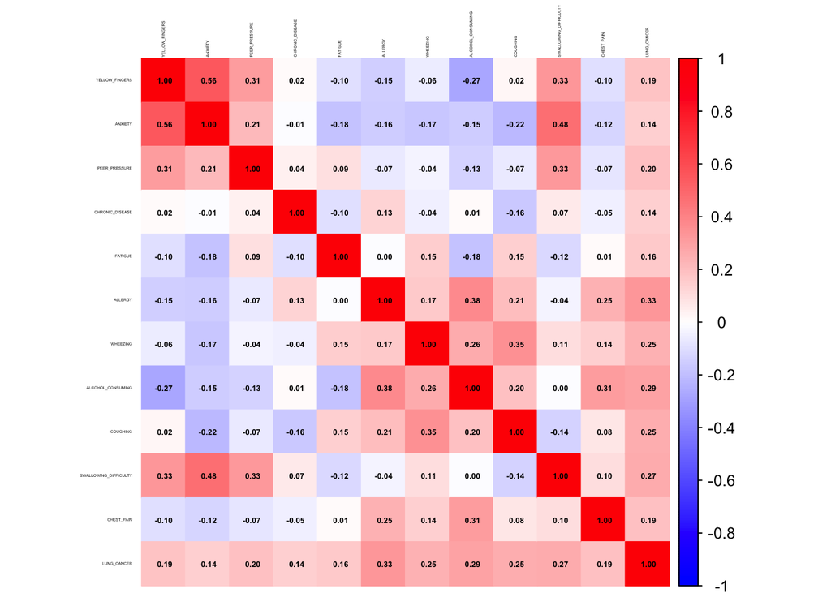

```r
corrplot(cn, method = "color", col = colorRampPalette(c("blue", "white", "red"))(200),
         type = "full",
         addCoef.col = "black",
         number.cex = 0.4,
         tl.cex = 0.2,
         tl.col = "black")
```

YELLOW_FINGERS and ANXIETY have a correlation of 0.56, showing a strong positive correlation. None of the other positive correlations are as high. For example, FATIGUE and CHRONIC_DISEASE have a correlation of -0.10, which is hardly linear. Most of the correlations between the variables are close to 0, which suggests that the variables may be independent or have a non-linear relationship.

```r
library(caret)
library(ROSE)
library(pROC)
library(rpart.plot)
# Create a new variable and convert the target variable to a factor
df_new$ANXYELFIN <- df_new$ANXIETY * df_new$YELLOW_FINGERS
X <- df_new[, !(names(df_new) %in% c("LUNG_CANCER"))]
y <- df_new$LUNG_CANCER
y <- factor(y, levels = c(0, 1))

# Data set partitioning (50% training set, 25% validation set, 25% test set)
set.seed(1234)
train_index <- createDataPartition(y, p = 0.5, list = FALSE)
X_train <- X[train_index, ]
y_train <- y[train_index]
X_temp <- X[-train_index, ]
y_temp <- y[-train_index]

set.seed(1234)
val_test_index <- createDataPartition(y_temp, p = 0.5, list = FALSE)
X_val <- X_temp[val_test_index, ]
y_val <- y_temp[val_test_index]
X_test <- X_temp[-val_test_index, ]
y_test <- y_temp[-val_test_index]

cat("\nDataset Sizes Before Resampling:\n")
```

```
Dataset Sizes Before Resampling:
```

```r
cat("Training set size: ", dim(X_train)[1], "\n")
```

```
Training set size:  138
```

```r
cat("Validation set size: ", dim(X_val)[1], "\n")
```

```
Validation set size:  70
```

```r
cat("Test set size: ", dim(X_test)[1], "\n")
```

```
Test set size:  68
```

```r
# Merge training data into a single data frame to accommodate resampling
train_data <- data.frame(y_train, X_train)

# Balancing training data
cat("\nApplying ROSE Oversampling...\n")
```

```
Applying ROSE Oversampling...
```

```r
train_data_rose <- ovun.sample(y_train ~ ., data = train_data, method = "both", p = 0.5, N = 1000, seed = 42)$data

# Checking data distribution after resampling
cat("\nClass Distribution After Resampling:\n")
```

```
Class Distribution After Resampling:
```

```r
print(table(train_data_rose$y_train))
```

```
  1   0
527 473
```

```r
# Re-split into x and y
X_train_rose <- train_data_rose[, -1]
y_train_rose <- train_data_rose$y_train

# K-Fold cross-validation parameters
set.seed(1234)
train_control <- trainControl(method = "cv", number = 5, verboseIter = TRUE)
```

```r
library(caret)
library(pROC)
library(e1071)  # SVM
library(randomForest)
library(class)  # KNN
# Check column names after resampling and dynamically get target variable names
target_var <- colnames(train_data_rose)[1]  # Dynamically get the target variable column name

# Perform K-Fold cross-validation
cat("\nPerforming K-Fold Cross Validation on Training Set...\n")
```

```
Performing K-Fold Cross Validation on Training Set...
```

```r
lr_model_cv <- train(
  as.formula(paste(target_var, "~ .")),  # Dynamic construction of formulas
  data = train_data_rose,
  method = "glm",
  family = binomial,
  trControl = train_control
)
# Output K-Fold cross-validation results
cat("\nCross-Validation Results:\n")
```

```
Cross-Validation Results:
```

```r
print(lr_model_cv)
```

```
Generalized Linear Model

1000 samples
  12 predictor
   2 classes: '1', '0'

No pre-processing
Resampling: Cross-Validated (5 fold)
Summary of sample sizes: 800, 800, 800, 799, 801
Resampling results:

  Accuracy   Kappa
  0.9679845  0.936062
```

```r
# Final model trained with K-Fold
lr_model <- lr_model_cv$finalModel

# Validation set prediction
y_val_prob <- predict(lr_model, newdata = data.frame(X_val), type = "response")
y_val_pred <- ifelse(y_val_prob > 0.5, 1, 0)

# Validation Set Performance Evaluation
confusion_matrix_val <- confusionMatrix(as.factor(y_val_pred), factor(y_val, levels = c(0, 1)))
val_accuracy <- confusion_matrix_val$overall["Accuracy"]
cat("\nValidation Set Accuracy:\n")
```

```
Validation Set Accuracy:
```

```r
print(val_accuracy)
```

```
 Accuracy
0.1428571
```

```r
# Test Set Prediction
y_test_prob <- predict(lr_model, newdata = data.frame(X_test), type = "response")
y_test_pred <- ifelse(y_test_prob > 0.5, 1, 0)

# Test Set Performance Evaluation
confusion_matrix_test <- confusionMatrix(as.factor(y_test_pred), factor(y_test, levels = c(0, 1)))
test_accuracy <- confusion_matrix_test$overall["Accuracy"]
cat("\nTest Set Accuracy:\n")
```

```
Test Set Accuracy:
```

```r
print(test_accuracy)
```

```
 Accuracy
0.1029412
```

```r
# Plotting ROC curves and calculating AUC
cat("\nPlotting ROC Curve for Test Set...\n")
```

```
Plotting ROC Curve for Test Set...
```

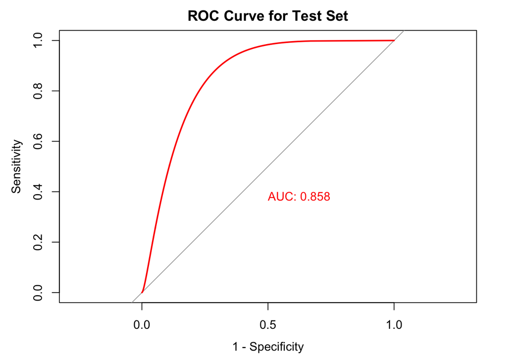

```r
# Test set ROC curve
roc_test <- roc(as.numeric(y_test) - 1, y_test_prob, smooth = TRUE)  # Adding Smoothing Parameters
auc_test <- auc(roc_test)

# roc plot
plot(
  roc_test,
  col = "red",
  main = "ROC Curve for Test Set",
  print.auc = TRUE,
  legacy.axes = TRUE,
  print.auc.y = 0.4
)
```

```r
# auc result
cat("\nTest Set AUC:\n")
```

```
Test Set AUC:
```

```r
print(auc_test)
```

```
Area under the curve: 0.8577
```

#### 3.0.2 Decision Tree Model

```r
# Training Decision Tree Models
cat("\nTraining Decision Tree with K-Fold Cross Validation on Resampled Data...\n")
```

```
Training Decision Tree with K-Fold Cross Validation on Resampled Data...
```

```r
tree_model_cv <- train(
  as.formula(paste(target_var, "~ .")),
  data = train_data_rose,
  method = "rpart",
  trControl = train_control,
  tuneGrid = expand.grid(cp = seq(0.01, 0.1, by = 0.01))
)
cat("\nDecision Tree Cross-Validation Results:\n")
```

```
Decision Tree Cross-Validation Results:
```

```r
print(tree_model_cv)
```

```
CART

1000 samples
  12 predictor
   2 classes: '1', '0'

No pre-processing
Resampling: Cross-Validated (5 fold)
Summary of sample sizes: 801, 799, 799, 800, 801
Resampling results across tuning parameters:

  cp    Accuracy   Kappa
  0.01  0.9470391  0.8940879
  0.02  0.8969678  0.7933646
  0.03  0.8829927  0.7650025
  0.04  0.8580022  0.7129426
  0.05  0.8380417  0.6731626
  0.06  0.8160112  0.6278442
  0.07  0.8150112  0.6258586
  0.08  0.8150112  0.6258586
  0.09  0.8150112  0.6258586
  0.10  0.8150112  0.6258586

Accuracy was used to select the optimal model using the largest value.
The final value used for the model was cp = 0.01.
```

```r
tree_model <- tree_model_cv$finalModel

cat("\nPlotting Decision Tree...\n")
```

```
Plotting Decision Tree...
```

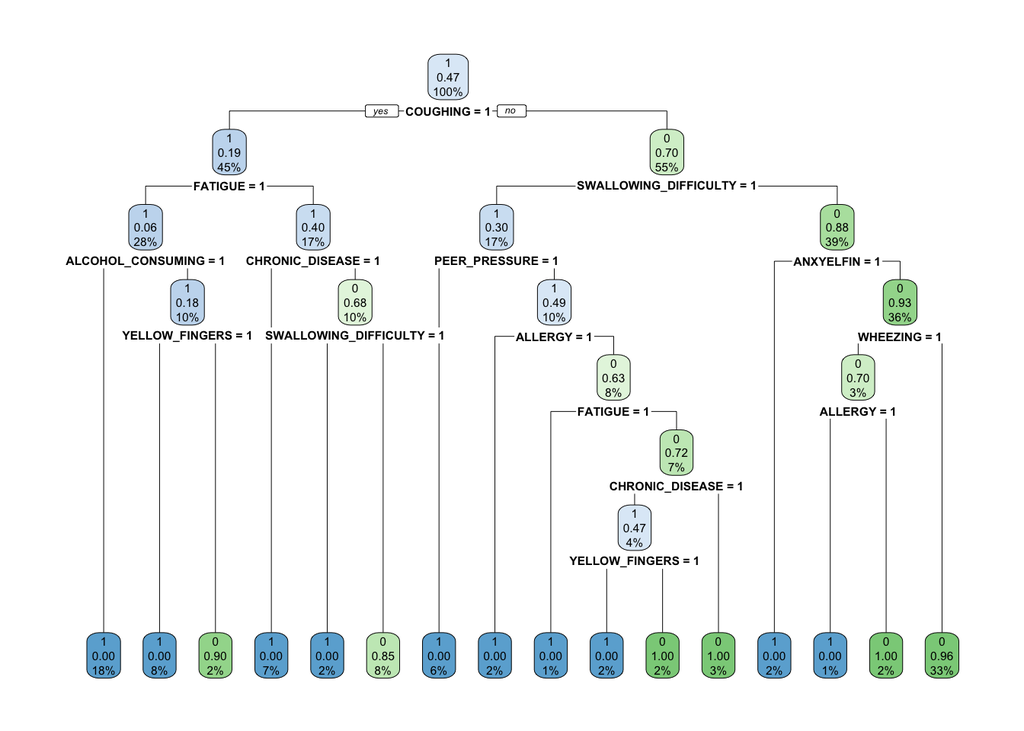

```r
rpart.plot(tree_model)
```

```r
y_val_prob_tree <- predict(tree_model, newdata = data.frame(X_val), type = "prob")[, 2]
y_val_pred_tree <- ifelse(y_val_prob_tree > 0.5, 1, 0)

confusion_matrix_val_tree <- confusionMatrix(as.factor(y_val_pred_tree), factor(y_val, levels = c(0, 1)))
val_accuracy_tree <- confusion_matrix_val_tree$overall["Accuracy"]
cat("\nValidation Set Accuracy (Decision Tree):\n")
```

```
Validation Set Accuracy (Decision Tree):
```

```r
print(val_accuracy_tree)
```

```
 Accuracy
0.1142857
```

```r
y_test_prob_tree <- predict(tree_model, newdata = data.frame(X_test), type = "prob")[, 2]
y_test_pred_tree <- ifelse(y_test_prob_tree > 0.5, 1, 0)

confusion_matrix_test_tree <- confusionMatrix(as.factor(y_test_pred_tree), factor(y_test, levels = c(0, 1)))
test_accuracy_tree <- confusion_matrix_test_tree$overall["Accuracy"]
cat("\nTest Set Accuracy (Decision Tree):\n")
```

```
Test Set Accuracy (Decision Tree):
```

```r
print(test_accuracy_tree)
```

```
 Accuracy
0.1323529
```

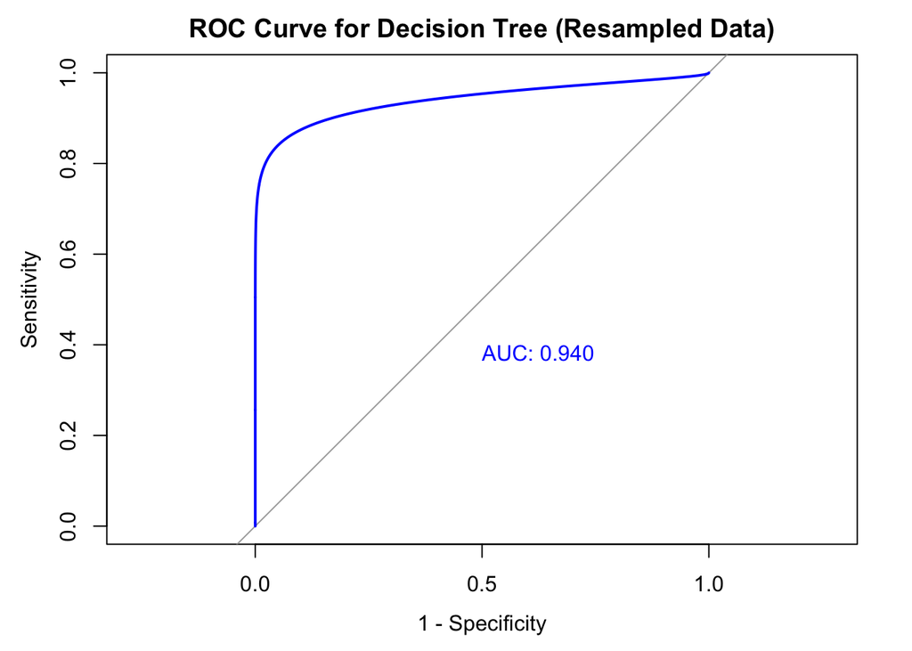

```r
roc_test_tree <- roc(as.numeric(y_test) - 1, y_test_prob_tree, smooth = TRUE)
auc_test_tree <- auc(roc_test_tree)
plot(
  roc_test_tree,
  col = "blue",
  main = "ROC Curve for Decision Tree (Resampled Data)",
  print.auc = TRUE,
  legacy.axes = TRUE,
  print.auc.y = 0.4
)
```

```r
cat("\nTest Set AUC (Decision Tree):\n")
```

```
Test Set AUC (Decision Tree):
```

```r
print(auc_test_tree)
```

```
Area under the curve: 0.9397
```

#### 3.0.3 Random Forest

```r
cat("\nTraining Random Forest with K-Fold Cross Validation...\n")
```

```
Training Random Forest with K-Fold Cross Validation...
```

```r
rf_model_cv <- train(
  as.formula(paste(target_var, "~ .")),
  data = train_data_rose,
  method = "rf",
  trControl = train_control,
  tuneGrid = expand.grid(mtry = sqrt(ncol(X_train_rose)))
)
cat("\nRandom Forest Cross-Validation Results:\n")
```

```
Random Forest Cross-Validation Results:
```

```r
print(rf_model_cv)
```

```
Random Forest

1000 samples
  12 predictor
   2 classes: '1', '0'

No pre-processing
Resampling: Cross-Validated (5 fold)
Summary of sample sizes: 799, 800, 800, 801, 800
Resampling results:

  Accuracy   Kappa
  0.9800199  0.9600471

Tuning parameter 'mtry' was held constant at a value of 3.464102
```

```r
rf_model <- rf_model_cv$finalModel

y_test_prob_rf <- predict(rf_model, newdata = data.frame(X_test), type = "prob")[, 2]
y_test_pred_rf <- ifelse(y_test_prob_rf > 0.5, 1, 0)

confusion_matrix_test_rf <- confusionMatrix(as.factor(y_test_pred_rf), factor(y_test, levels = c(0, 1)))
cat("\nTest Set Accuracy (Random Forest):\n")
```

```
Test Set Accuracy (Random Forest):
```

```r
print(confusion_matrix_test_rf$overall["Accuracy"])
```

```
 Accuracy
0.1176471
```

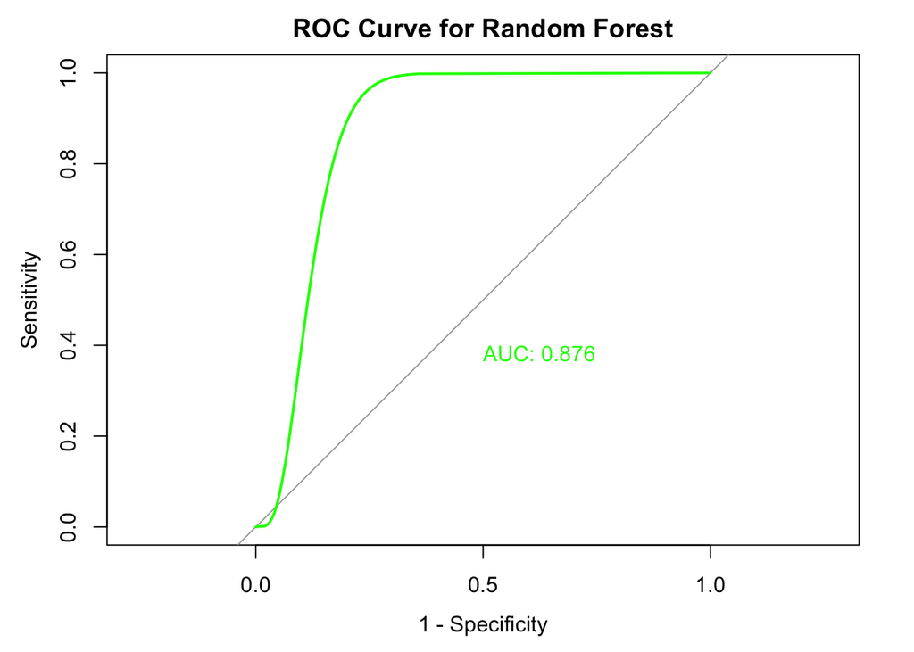

```r
roc_test_rf <- roc(as.numeric(y_test) - 1, y_test_prob_rf, smooth = TRUE)
auc_test_rf <- auc(roc_test_rf)
plot(
  roc_test_rf,
  col = "green",
  main = "ROC Curve for Random Forest",
  print.auc = TRUE,
  legacy.axes = TRUE,
  print.auc.y = 0.4
)
```

```r
cat("\nTest Set AUC (Random Forest):\n")
```

```
Test Set AUC (Random Forest):
```

```r
print(auc_test_rf)
```

```
Area under the curve: 0.8758
```

#### 3.0.4 **Support Vector Classifier (SVC)**

```r
library(kernlab)
cat("\nTraining Support Vector Classifier (SVC) with K-Fold Cross Validation...\n")
```

```
Training Support Vector Classifier (SVC) with K-Fold Cross Validation...
```

```r
svc_model <- ksvm(
  x = as.matrix(X_train_rose),
  y = as.factor(y_train_rose),
  type = "C-svc",
  kernel = "rbfdot",
  C = 1,
  prob.model = TRUE,
  trControl = train_control
)

cat("\nSVC Model Trained Successfully.\n")
```

```
SVC Model Trained Successfully.
```

```r
print(svc_model)
```

```
Support Vector Machine object of class "ksvm"

SV type: C-svc  (classification)
 parameter : cost C = 1

Gaussian Radial Basis kernel function.
 Hyperparameter : sigma =  0.0545798914143967

Number of Support Vectors : 140

Objective Function Value : -83.8092
Training error : 0.02
Probability model included.
```

```r
# Test Set Evaluation
# Probability values for prediction categories
y_test_prob_svc <- predict(svc_model, newdata = as.matrix(X_test), type = "probabilities")[, 2]
y_test_pred_svc <- ifelse(y_test_prob_svc > 0.5, 1, 0)

confusion_matrix_test_svc <- confusionMatrix(as.factor(y_test_pred_svc), factor(y_test, levels = c(0, 1)))
cat("\nTest Set Accuracy (SVC):\n")
```

```
Test Set Accuracy (SVC):
```

```r
print(confusion_matrix_test_svc$overall["Accuracy"])
```

```
 Accuracy
0.1029412
```

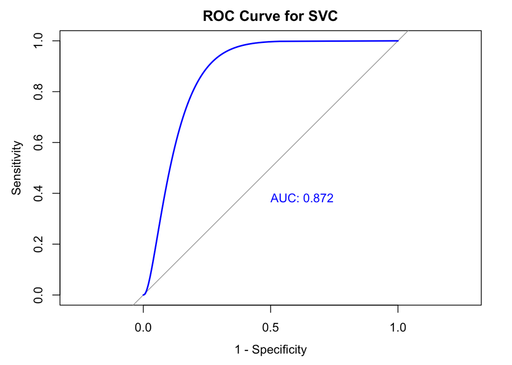

```r
roc_test_svc <- roc(as.numeric(y_test) - 1, y_test_prob_svc, smooth = TRUE)
auc_test_svc <- auc(roc_test_svc)
plot(
  roc_test_svc,
  col = "blue",
  main = "ROC Curve for SVC",
  print.auc = TRUE,
  legacy.axes = TRUE,
  print.auc.y = 0.4
)
```

```r
cat("\nTest Set AUC (SVC):\n")
```

```
Test Set AUC (SVC):
```

```r
print(auc_test_svc)
```

```
Area under the curve: 0.8722
```

#### 3.0.5 Gaussian Naive Bayes

```r
library(naivebayes)
cat("\nTraining Gaussian Naive Bayes...\n")
```

```
Training Gaussian Naive Bayes...
```

```r
gnb_model_cv <- train(
  as.formula(paste(target_var, "~ .")),
  data = train_data_rose,
  method = "naive_bayes",
  trControl = train_control
)
cat("\nGaussian Naive Bayes Cross-Validation Results:\n")
```

```
Gaussian Naive Bayes Cross-Validation Results:
```

```r
print(gnb_model_cv)
```

```
Naive Bayes

1000 samples
  12 predictor
   2 classes: '1', '0'

No pre-processing
Resampling: Cross-Validated (5 fold)
Summary of sample sizes: 799, 799, 801, 800, 801
Resampling results across tuning parameters:

  usekernel  Accuracy   Kappa
  FALSE      0.8769875  0.7514213
   TRUE      0.8660122  0.7321218

Tuning parameter 'laplace' was held constant at a value of 0
Tuning
 parameter 'adjust' was held constant at a value of 1
Accuracy was used to select the optimal model using the largest value.
The final values used for the model were laplace = 0, usekernel = FALSE
 and adjust = 1.
```

```r
gnb_model <- gnb_model_cv$finalModel

y_test_prob_gnb <- predict(gnb_model, newdata = data.frame(X_test), type = "prob")[, 2]
y_test_pred_gnb <- ifelse(y_test_prob_gnb > 0.5, 1, 0)

confusion_matrix_test_gnb <- confusionMatrix(as.factor(y_test_pred_gnb), factor(y_test, levels = c(0, 1)))
cat("\nTest Set Accuracy (Gaussian Naive Bayes):\n")
```

```
Test Set Accuracy (Gaussian Naive Bayes):
```

```r
print(confusion_matrix_test_gnb$overall["Accuracy"])
```

```
 Accuracy
0.1470588
```

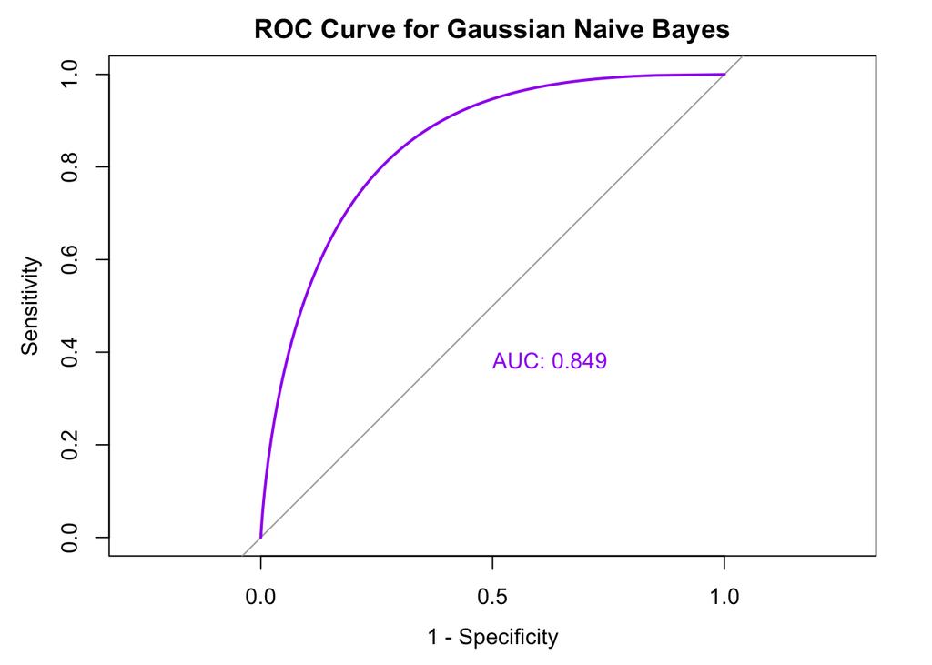

```r
roc_test_gnb <- roc(as.numeric(y_test) - 1, y_test_prob_gnb, smooth = TRUE)
auc_test_gnb <- auc(roc_test_gnb)
plot(
  roc_test_gnb,
  col = "purple",
  main = "ROC Curve for Gaussian Naive Bayes",
  print.auc = TRUE,
  legacy.axes = TRUE,
  print.auc.y = 0.4
)
```

```r
cat("\nTest Set AUC (Gaussian Naive Bayes):\n")
```

```
Test Set AUC (Gaussian Naive Bayes):
```

```r
print(auc_test_gnb)
```

```
Area under the curve: 0.8489
```

#### 3.0.6 K Nearest Neighbor

```r
cat("\nTraining K-Nearest Neighbor (KNN) with K-Fold Cross Validation...\n")
```

```
Training K-Nearest Neighbor (KNN) with K-Fold Cross Validation...
```

```r
knn_model_cv <- train(
  as.formula(paste(target_var, "~ .")),
  data = train_data_rose,
  method = "knn",
  trControl = train_control,
  tuneGrid = expand.grid(k = seq(3, 15, by = 2))
)
cat("\nKNN Cross-Validation Results:\n")
```

```
KNN Cross-Validation Results:
```

```r
print(knn_model_cv)
```

```
k-Nearest Neighbors

1000 samples
  12 predictor
   2 classes: '1', '0'

No pre-processing
Resampling: Cross-Validated (5 fold)
Summary of sample sizes: 799, 800, 801, 799, 801
Resampling results across tuning parameters:

  k   Accuracy   Kappa
   3  0.9720345  0.9440927
   5  0.9580192  0.9161842
   7  0.9460040  0.8923398
   9  0.9390039  0.8784714
  11  0.9379988  0.8764807
  13  0.9359888  0.8725017
  15  0.9359988  0.8725168

Accuracy was used to select the optimal model using the largest value.
The final value used for the model was k = 3.
```

```r
knn_model <- knn_model_cv$finalModel

y_test_prob_knn <- predict(knn_model, newdata = data.frame(X_test), type = "prob")[, 2]
y_test_pred_knn <- ifelse(y_test_prob_knn > 0.5, 1, 0)

confusion_matrix_test_knn <- confusionMatrix(as.factor(y_test_pred_knn), factor(y_test, levels = c(0, 1)))
cat("\nTest Set Accuracy (KNN):\n")
```

```
Test Set Accuracy (KNN):
```

```r
print(confusion_matrix_test_knn$overall["Accuracy"])
```

```
 Accuracy
0.1029412
```

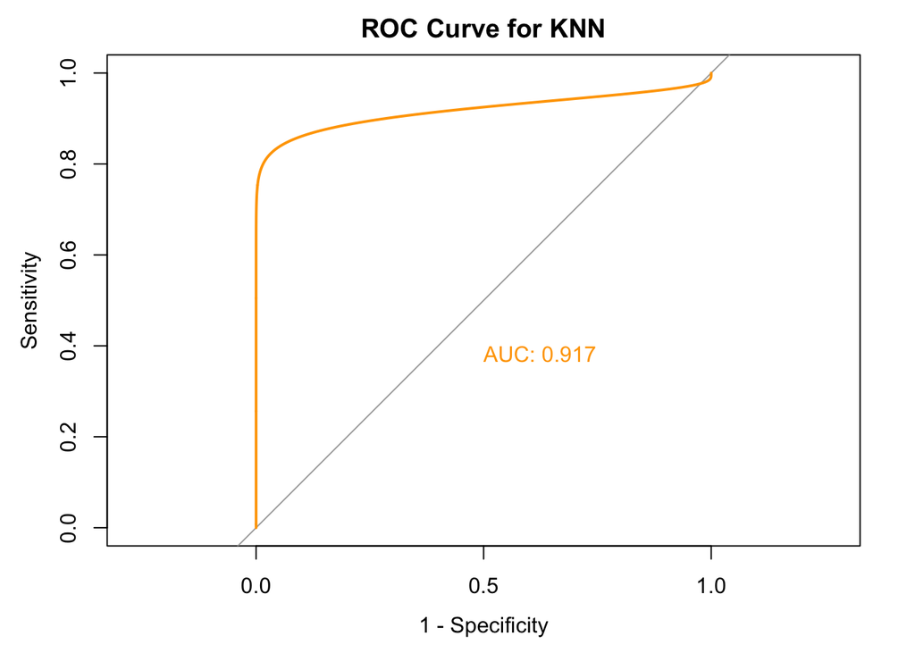

```r
roc_test_knn <- roc(as.numeric(y_test) - 1, y_test_prob_knn, smooth = TRUE)
auc_test_knn <- auc(roc_test_knn)
plot(
  roc_test_knn,
  col = "orange",
  main = "ROC Curve for KNN",
  print.auc = TRUE,
  legacy.axes = TRUE,
  print.auc.y = 0.4
)
```

```r
cat("\nTest Set AUC (KNN):\n")
```

```
Test Set AUC (KNN):
```

```r
print(auc_test_knn)
```

```
Area under the curve: 0.9174
```